# *Citi Bike Data*

### Cleaning

```python
# Save the original data set and save as a new, cleaned version while I clean things up
df_cleaned = df.copy()
```

*Define: Converting gender to Male/Female.*

```python
df_cleaned.gender.replace(to_replace = [0, 1, 2], value = [np.nan, 'Male', 'Female'], inplace=True)
```

```python
df_cleaned.head()
```

|  | tripduration | starttime | stoptime | start station id | start station name | start station latitude | start station longitude | end station id | end station name | end station latitude | end station longitude | bikeid | usertype | birth year | gender |
| --- | --- | --- | --- | --- | --- | --- | --- | --- | --- | --- | --- | --- | --- | --- | --- |
| 0 | 226 | 2020-01-01 00:04:50.1920 | 2020-01-01 00:08:37.0370 | 3186 | Grove St PATH | 40.719586 | -74.043117 | 3211 | Newark Ave | 40.721525 | -74.046305 | 29444 | Subscriber | 1984 | Female |
| 1 | 377 | 2020-01-01 00:16:01.6700 | 2020-01-01 00:22:19.0800 | 3186 | Grove St PATH | 40.719586 | -74.043117 | 3269 | Brunswick & 6th | 40.726012 | -74.050389 | 26305 | Subscriber | 1989 | Female |
| 2 | 288 | 2020-01-01 00:17:33.8770 | 2020-01-01 00:22:22.4420 | 3186 | Grove St PATH | 40.719586 | -74.043117 | 3269 | Brunswick & 6th | 40.726012 | -74.050389 | 29268 | Customer | 1989 | Male |
| 3 | 435 | 2020-01-01 00:32:05.9020 | 2020-01-01 00:39:21.0660 | 3195 | Sip Ave | 40.730897 | -74.063913 | 3280 | Astor Place | 40.719282 | -74.071262 | 29278 | Customer | 1969 | NaN |
| 4 | 231 | 2020-01-01 00:46:19.6780 | 2020-01-01 00:50:11.3440 | 3186 | Grove St PATH | 40.719586 | -74.043117 | 3276 | Marin Light Rail | 40.714584 | -74.042817 | 29276 | Subscriber | 1983 | Female |

##### Define: Converting several of the columns to the appropriate data types.

- Starting and ending times to the timestamp format
- User type and gender for all to category format
- Bike ID, start station ID, and end station ID to object format

##### Code

```python
# Changing the format to datetime
df_cleaned.starttime = pd.to_datetime(df_cleaned.starttime)
df_cleaned.stoptime = pd.to_datetime(df_cleaned.stoptime)
```

```python
# Changing the user_type, member_gender to category format
df_cleaned.usertype = df_cleaned.usertype.astype('category')
df_cleaned.gender = df_cleaned.gender.astype('category')
```

```python
df_cleaned.info()
```

```
<class 'pandas.core.frame.DataFrame'>
Int64Index: 101046 entries, 0 to 25076
Data columns (total 15 columns):
 #   Column                   Non-Null Count   Dtype
---  ------                   --------------   -----
 0   tripduration             101046 non-null  int64
 1   starttime                101046 non-null  datetime64[ns]
 2   stoptime                 101046 non-null  datetime64[ns]
 3   start station id         101046 non-null  int64
 4   start station name       101046 non-null  object
 5   start station latitude   101046 non-null  float64
 6   start station longitude  101046 non-null  float64
 7   end station id           101046 non-null  int64
 8   end station name         101046 non-null  object
 9   end station latitude     101046 non-null  float64
 10  end station longitude    101046 non-null  float64
 11  bikeid                   101046 non-null  int64
 12  usertype                 101046 non-null  category
 13  birth year               101046 non-null  int64
 14  gender                   90493 non-null   category
dtypes: category(2), datetime64[ns](2), float64(4), int64(5), object(2)
memory usage: 11.0+ MB
```

```python
# Changing the bike_id, start_station_id, and end_station_id to object
df_cleaned.bikeid = df_cleaned.bikeid.astype(str)
df_cleaned['start station id'] = df_cleaned['start station id'].astype(str)
df_cleaned['end station id'] = df_cleaned['end station id'].astype(str)
```

##### Test:

```python
df_cleaned.info()
```

```
<class 'pandas.core.frame.DataFrame'>
Int64Index: 101046 entries, 0 to 25076
Data columns (total 15 columns):
 #   Column                   Non-Null Count   Dtype
---  ------                   --------------   -----
 0   tripduration             101046 non-null  int64
 1   starttime                101046 non-null  datetime64[ns]
 2   stoptime                 101046 non-null  datetime64[ns]
 3   start station id         101046 non-null  object
 4   start station name       101046 non-null  object
 5   start station latitude   101046 non-null  float64
 6   start station longitude  101046 non-null  float64
 7   end station id           101046 non-null  object
 8   end station name         101046 non-null  object
 9   end station latitude     101046 non-null  float64
 10  end station longitude    101046 non-null  float64
 11  bikeid                   101046 non-null  object
 12  usertype                 101046 non-null  category
 13  birth year               101046 non-null  int64
 14  gender                   90493 non-null   category
dtypes: category(2), datetime64[ns](2), float64(4), int64(2), object(5)
memory usage: 11.0+ MB
```

##### Code

```python
# Subtracting the member_birth_year from the current year to get the ages of the members
df_cleaned['member_age'] = 2020 - df_cleaned['birth year']
```

##### Test:

```python
df_cleaned.head()
```

|  | tripduration | starttime | stoptime | start station id | start station name | start station latitude | start station longitude | end station id | end station name | end station latitude | end station longitude | bikeid | usertype | birth year | gender | member_age |
| --- | --- | --- | --- | --- | --- | --- | --- | --- | --- | --- | --- | --- | --- | --- | --- | --- |
| 0 | 226 | 2020-01-01 00:04:50.192 | 2020-01-01 00:08:37.037 | 3186 | Grove St PATH | 40.719586 | -74.043117 | 3211 | Newark Ave | 40.721525 | -74.046305 | 29444 | Subscriber | 1984 | Female | 36 |
| 1 | 377 | 2020-01-01 00:16:01.670 | 2020-01-01 00:22:19.080 | 3186 | Grove St PATH | 40.719586 | -74.043117 | 3269 | Brunswick & 6th | 40.726012 | -74.050389 | 26305 | Subscriber | 1989 | Female | 31 |
| 2 | 288 | 2020-01-01 00:17:33.877 | 2020-01-01 00:22:22.442 | 3186 | Grove St PATH | 40.719586 | -74.043117 | 3269 | Brunswick & 6th | 40.726012 | -74.050389 | 29268 | Customer | 1989 | Male | 31 |
| 3 | 435 | 2020-01-01 00:32:05.902 | 2020-01-01 00:39:21.066 | 3195 | Sip Ave | 40.730897 | -74.063913 | 3280 | Astor Place | 40.719282 | -74.071262 | 29278 | Customer | 1969 | NaN | 51 |
| 4 | 231 | 2020-01-01 00:46:19.678 | 2020-01-01 00:50:11.344 | 3186 | Grove St PATH | 40.719586 | -74.043117 | 3276 | Marin Light Rail | 40.714584 | -74.042817 | 29276 | Subscriber | 1983 | Female | 37 |

#### *Define: Renaming Columns.*

#### *Code*

```python
# Names to be assigned for convenience
columns_changed = ['trip_duration', 'start_time', 'stop_time', 'start_station_id',
       'start_station_name', 'start_station_latitude',
       'start_station_longitude', 'end_station_id', 'end_station_name',
       'end_station_latitude', 'end_station_longitude', 'bike_id',
       'user_type', 'birth_year', 'gender', 'member_age']
```

```python
# Function to rename column names.
def column_rename():
    for i in range(len(columns_changed)):
        df_cleaned.rename(columns ={df_cleaned.columns.values[i] : columns_changed[i]}, inplace = True)
column_rename()
```

#### *Test*

```python
df_cleaned.info()
```

```
<class 'pandas.core.frame.DataFrame'>
Int64Index: 101046 entries, 0 to 25076
Data columns (total 16 columns):
 #   Column                   Non-Null Count   Dtype
---  ------                   --------------   -----
 0   trip_duration            101046 non-null  int64
 1   start_time               101046 non-null  datetime64[ns]
 2   stop_time                101046 non-null  datetime64[ns]
 3   start_station_id         101046 non-null  object
 4   start_station_name       101046 non-null  object
 5   start_station_latitude   101046 non-null  float64
 6   start_station_longitude  101046 non-null  float64
 7   end_station_id           101046 non-null  object
 8   end_station_name         101046 non-null  object
 9   end_station_latitude     101046 non-null  float64
 10  end_station_longitude    101046 non-null  float64
 11  bike_id                  101046 non-null  object
 12  user_type                101046 non-null  category
 13  birth_year               101046 non-null  int64
 14  gender                   90493 non-null   category
 15  member_age               101046 non-null  int64
dtypes: category(2), datetime64[ns](2), float64(4), int64(3), object(5)
memory usage: 11.8+ MB
```

##### Define: Add columns for the start month, day of the week, and hour, along with figuring out the trip duration in minutes so I can create visuals based on workable units

##### Code

```python
# Start time month (January - December)
df_cleaned['start_time_month'] = df_cleaned['start_time'].dt.strftime('%B')
```

```python
# Start time month (1-12)
df_cleaned['start_time_month_num'] = df_cleaned['start_time'].dt.month.astype(int)
```

```python
# Start time weekday
df_cleaned['start_time_weekday'] = df_cleaned['start_time'].dt.strftime('%a')
```

```python
# Start and end time hour
df_cleaned['start_time_hour'] = df_cleaned['start_time'].dt.hour
df_cleaned['stop_time_hour'] = df_cleaned['stop_time'].dt.hour
```

```python
# Duration in seconds to duration in minutes
df_cleaned['duration_min'] = df_cleaned['trip_duration']/60
df_cleaned['duration_min'] = df_cleaned['duration_min'].astype(int)
```

##### Test:

```python
df_cleaned.sample(5)
```

|  | trip_duration | start_time | stop_time | start_station_id | start_station_name | start_station_latitude | start_station_longitude | end_station_id | end_station_name | end_station_latitude | ... | user_type | birth_year | gender | member_age | start_time_month | start_time_month_num | start_time_weekday | start_time_hour | stop_time_hour | duration_min |
| --- | --- | --- | --- | --- | --- | --- | --- | --- | --- | --- | --- | --- | --- | --- | --- | --- | --- | --- | --- | --- | --- |
| 5988 | 216 | 2020-03-09 07:51:31.523 | 2020-03-09 07:55:08.442 | 3195 | Sip Ave | 40.730897 | -74.063913 | 3194 | McGinley Square | 40.725340 | ... | Subscriber | 1955 | Male | 65 | March | 3 | Mon | 7 | 7 | 3 |
| 13865 | 467 | 2020-01-16 17:35:00.687 | 2020-01-16 17:42:47.948 | 3639 | Harborside | 40.719252 | -74.034234 | 3205 | JC Medical Center | 40.716540 | ... | Subscriber | 1990 | Male | 30 | January | 1 | Thu | 17 | 17 | 7 |
| 21889 | 225 | 2020-02-28 09:03:54.046 | 2020-02-28 09:07:39.591 | 3270 | Jersey & 6th St | 40.725289 | -74.045572 | 3186 | Grove St PATH | 40.719586 | ... | Subscriber | 1965 | Female | 55 | February | 2 | Fri | 9 | 9 | 3 |
| 24267 | 413 | 2020-01-30 08:41:16.991 | 2020-01-30 08:48:10.329 | 3186 | Grove St PATH | 40.719586 | -74.043117 | 3269 | Brunswick & 6th | 40.726012 | ... | Subscriber | 1987 | Male | 33 | January | 1 | Thu | 8 | 8 | 6 |
| 18810 | 387 | 2020-02-24 17:41:46.617 | 2020-02-24 17:48:14.412 | 3186 | Grove St PATH | 40.719586 | -74.043117 | 3267 | Morris Canal | 40.712419 | ... | Subscriber | 1983 | Male | 37 | February | 2 | Mon | 17 | 17 | 6 |

5 rows × 22 columns

```python
df_cleaned.info()
```

```
<class 'pandas.core.frame.DataFrame'>
Int64Index: 101046 entries, 0 to 25076
Data columns (total 22 columns):
 #   Column                   Non-Null Count   Dtype
---  ------                   --------------   -----
 0   trip_duration            101046 non-null  int64
 1   start_time               101046 non-null  datetime64[ns]
 2   stop_time                101046 non-null  datetime64[ns]
 3   start_station_id         101046 non-null  object
 4   start_station_name       101046 non-null  object
 5   start_station_latitude   101046 non-null  float64
 6   start_station_longitude  101046 non-null  float64
 7   end_station_id           101046 non-null  object
 8   end_station_name         101046 non-null  object
 9   end_station_latitude     101046 non-null  float64
 10  end_station_longitude    101046 non-null  float64
 11  bike_id                  101046 non-null  object
 12  user_type                101046 non-null  category
 13  birth_year               101046 non-null  int64
 14  gender                   90493 non-null   category
 15  member_age               101046 non-null  int64
 16  start_time_month         101046 non-null  object
 17  start_time_month_num     101046 non-null  int32
 18  start_time_weekday       101046 non-null  object
 19  start_time_hour          101046 non-null  int64
 20  stop_time_hour           101046 non-null  int64
 21  duration_min             101046 non-null  int32
dtypes: category(2), datetime64[ns](2), float64(4), int32(2), int64(5), object(7)
memory usage: 15.6+ MB
```

##### Define: Calculate the total distance traveled using the latitude and longitude in the data set

##### Code

*Calculations are derived from the **haversine formula** which is used to calculate the great-circle distance between two points, i.e. the shortest distance over the earth's surface. Can be found on google and stackoverflow.*

```python
import math
from math import radians, sin, cos, acos

def distance(origin, destination):

    lat1, long1 = origin
    lat2, long2 = destination
    radius = 6371
    dlat = math.radians(lat2 - lat1)
    dlong = math.radians(long2 - long1)

    a = (math.sin(dlat / 2) * math.sin(dlat / 2) + math.cos(math.radians(lat1)) * math.cos(math.radians(lat2)) * math.sin(dlong / 2) * math.sin(dlong / 2))
    c = 2 * math.atan2(math.sqrt(a), math.sqrt(1 - a))
    d = radius * c

    return d
```

```python
# Using the calcuated math on our columns for lat and long
df_cleaned['distance_km'] = df_cleaned.apply(lambda x: distance((x['start_station_latitude'], x['start_station_longitude']), (x['end_station_latitude'], x['end_station_longitude'])), axis=1)
```

*Test*

```python
df_cleaned.info()
```

```
<class 'pandas.core.frame.DataFrame'>
Int64Index: 101046 entries, 0 to 25076
Data columns (total 23 columns):
 #   Column                   Non-Null Count   Dtype
---  ------                   --------------   -----
 0   trip_duration            101046 non-null  int64
 1   start_time               101046 non-null  datetime64[ns]
 2   stop_time                101046 non-null  datetime64[ns]
 3   start_station_id         101046 non-null  object
 4   start_station_name       101046 non-null  object
 5   start_station_latitude   101046 non-null  float64
 6   start_station_longitude  101046 non-null  float64
 7   end_station_id           101046 non-null  object
 8   end_station_name         101046 non-null  object
 9   end_station_latitude     101046 non-null  float64
 10  end_station_longitude    101046 non-null  float64
 11  bike_id                  101046 non-null  object
 12  user_type                101046 non-null  category
 13  birth_year               101046 non-null  int64
 14  gender                   90493 non-null   category
 15  member_age               101046 non-null  int64
 16  start_time_month         101046 non-null  object
 17  start_time_month_num     101046 non-null  int32
 18  start_time_weekday       101046 non-null  object
 19  start_time_hour          101046 non-null  int64
 20  stop_time_hour           101046 non-null  int64
 21  duration_min             101046 non-null  int32
 22  distance_km              101046 non-null  float64
dtypes: category(2), datetime64[ns](2), float64(5), int32(2), int64(5), object(7)
memory usage: 16.4+ MB
```

```python
df_cleaned.sample(5)
```

|  | trip_duration | start_time | stop_time | start_station_id | start_station_name | start_station_latitude | start_station_longitude | end_station_id | end_station_name | end_station_latitude | ... | birth_year | gender | member_age | start_time_month | start_time_month_num | start_time_weekday | start_time_hour | stop_time_hour | duration_min | distance_km |
| --- | --- | --- | --- | --- | --- | --- | --- | --- | --- | --- | --- | --- | --- | --- | --- | --- | --- | --- | --- | --- | --- |
| 6730 | 326 | 2020-01-09 18:05:33.923 | 2020-01-09 18:10:59.964 | 3792 | Columbus Dr at Exchange Pl | 40.716870 | -74.032810 | 3187 | Warren St | 40.721124 | ... | 1990 | Female | 30 | January | 1 | Thu | 18 | 18 | 5 | 0.647147 |
| 11560 | 991 | 2020-03-14 21:55:50.473 | 2020-03-14 22:12:22.197 | 3195 | Sip Ave | 40.730897 | -74.063913 | 3191 | Union St | 40.718211 | ... | 1977 | Male | 43 | March | 3 | Sat | 21 | 22 | 16 | 2.180194 |
| 678 | 603 | 2020-01-02 10:21:40.505 | 2020-01-02 10:31:43.749 | 3483 | Montgomery St | 40.719420 | -74.050990 | 3678 | Fairmount Ave | 40.725726 | ... | 1981 | Male | 39 | January | 1 | Thu | 10 | 10 | 10 | 1.901163 |
| 4195 | 2061 | 2020-04-13 21:29:27.791 | 2020-04-13 22:03:48.843 | 3481 | York St | 40.716490 | -74.041050 | 3193 | Lincoln Park | 40.724605 | ... | 2001 | Male | 19 | April | 4 | Mon | 21 | 22 | 34 | 3.274930 |
| 20011 | 285 | 2020-02-26 07:17:35.930 | 2020-02-26 07:22:21.756 | 3279 | Dixon Mills | 40.721630 | -74.049968 | 3185 | City Hall | 40.717733 | ... | 1993 | Female | 27 | February | 2 | Wed | 7 | 7 | 4 | 0.673866 |

5 rows × 23 columns

#### *Creating age bins*

```python
#Creating age bins
df_cleaned['age_bins'] = df_cleaned['member_age'].apply(lambda x: '10 - 20' if 10 < x <= 20
                        else '20 - 30' if 20 < x <= 30 else '30 - 40' if 30 < x <= 40
                        else '40 - 50' if 40 < x <= 50 else '50 - 60' if 50 < x <= 60
                        else '60 - 80' if 60 < x <= 80 else x)
```

##### Saving cleaned data to new file

```python
df_cleaned.to_csv('citi_bike_clean.csv', index = False)
```

### What is the structure of your dataset?

> - The Citi Bike data is straightforward and intuitive to understand. This data has been collected efficiently, providing a valuable collection of data to work with and draw conclusions from.
> - This notebook uses data collected from January to May 2020. There were approximately 101046 bike rides in New York as reported.

*The column header descriptions are as follows (each trip is anonymized):*

- Trip Duration (seconds)
- Start Time and Date
- End Time and Date
- Start Station ID
- Start Station Name
- Start Station Latitude
- Start Station Longitude
- End Station ID
- End Station Name
- End Station Latitude
- End Station Longitude
- Bike ID
- User Type (Customer = 24-hour pass or 3-day pass user; Subscriber = Annual Member)
- Member Year of Birth
- Member Gender

*Added the following columns in cleaning:*

- Member Age
- Start Time Month
- Start Time Month Number
- Start Time Day of the Week
- Start Time Hour
- Distance (km)

### What is/are the main feature(s) of interest in your dataset?

*The main features include data related to the start and end of a ride. This can be used to calculate when bikes are in high or low demand. There is also ample data related to the users of the bike service including their age, gender, and whether they are a paying member or a casual user. These features can be used to make business decisions such as which age group to target in marketing campaigns, or which day of the week bikes should be most available.*

### What features in the dataset do you think will help support your investigation into your feature(s) of interest?

*The start and end times, and related time-based information will be utilized. I will use the customer related data, as well as the distance to understand the user-driven data behind each ride.*

## Univariate Exploration

*In this section, I investigate relationships of variables in the data.*

```python
# Using base_color  and using whitegrid for good looking visualizations and a common color for every people including color blind.
base_color = sb.color_palette()[0]
sb.set_style('whitegrid');
```

### *Monthly usage of the Citi Bike system*

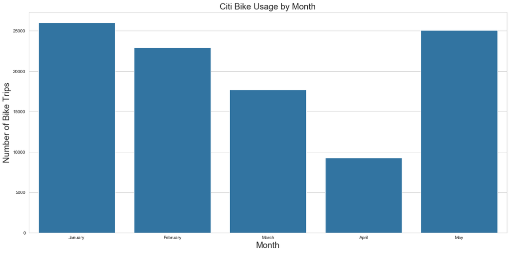

```python
# Monthly usage of the Citi Bike system
plt.figure(figsize = (19,9))
sb.countplot(data = df_cleaned, x = 'start_time_month', color = base_color);

plt.xlabel('Month',fontsize = 19)
plt.ylabel('Number of Bike Trips',fontsize = 19)
plt.title('Citi Bike Usage by Month', fontsize = 19);
```

**Summer and Winter** *months are more popular of bike riding, which is because in winters people mainly use bikes to complement travel with the exercise, as we can see **January and February** has high number of bike trips than trips reduced in **March and April** as summer approaches. **Then number of trips increases as May** contains vacations for many people therefore, people used the service to spend their free time.*

### *Weekday usage of the Citi bike system*

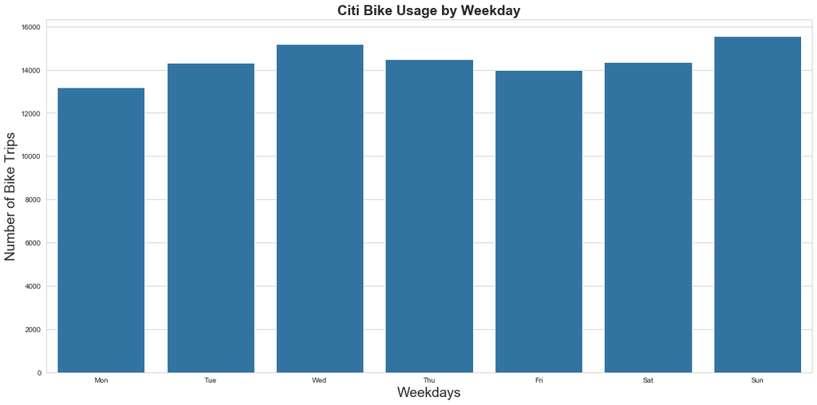

```python
# Weekday usage of the Citi bike system
plt.figure(figsize = (19,9))
weekday = ['Mon', 'Tue', 'Wed', 'Thu', 'Fri', 'Sat', 'Sun']

sb.countplot(data=df_cleaned, x='start_time_weekday', color = base_color, order = weekday)

plt.xlabel('Weekdays', fontsize = 19)
plt.ylabel('Number of Bike Trips', fontsize = 19)

plt.title('Citi Bike Usage by Weekday', fontsize = 19, fontweight='bold');
```

*The data is almost uniform, which suggests that weekdays might not have anything to do with number of trips. However, there are more trips on Sundays maybe because of holiday.*

### *Hourly usage of the Citi Bike System*

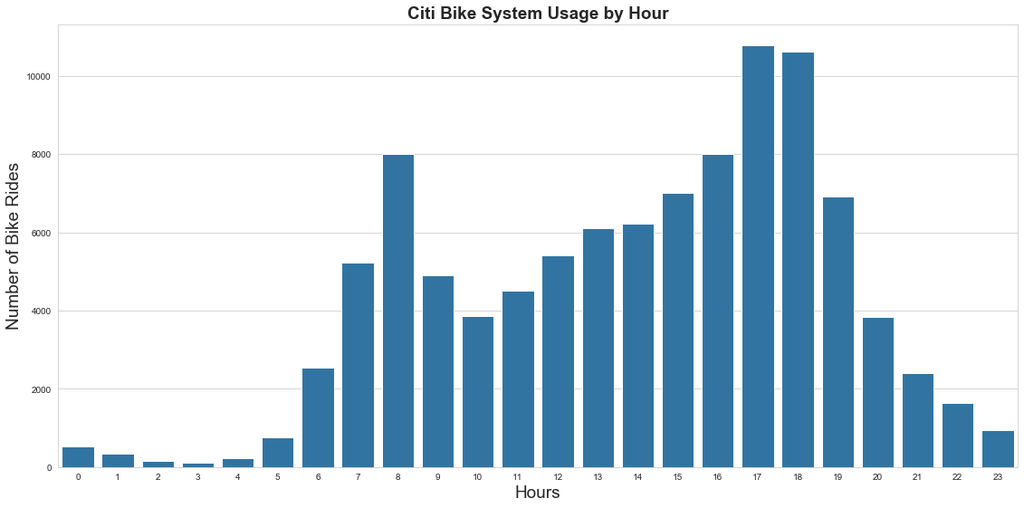

```python
# Hourly usage of the Citi Bike System
plt.figure(figsize = (19,9))
sb.countplot(data = df_cleaned, x='start_time_hour', color = base_color)

plt.xlabel('Hours', fontsize = 19)
plt.ylabel('Number of Bike Rides', fontsize = 19)

plt.title('Citi Bike System Usage by Hour', fontsize=19, fontweight='bold');
```

*The bikes are most used in the evening around 5 - 6 PM which makes sense as at that time many people go out for a walk, or meet people or for exercise. Also, exercise and walk in park also occurs in the morning therefore, there are lots of trips in the morning around 7-8 AM.*

### *Duration of bike rides*

*Duration of the bike rides - in SECONDS*

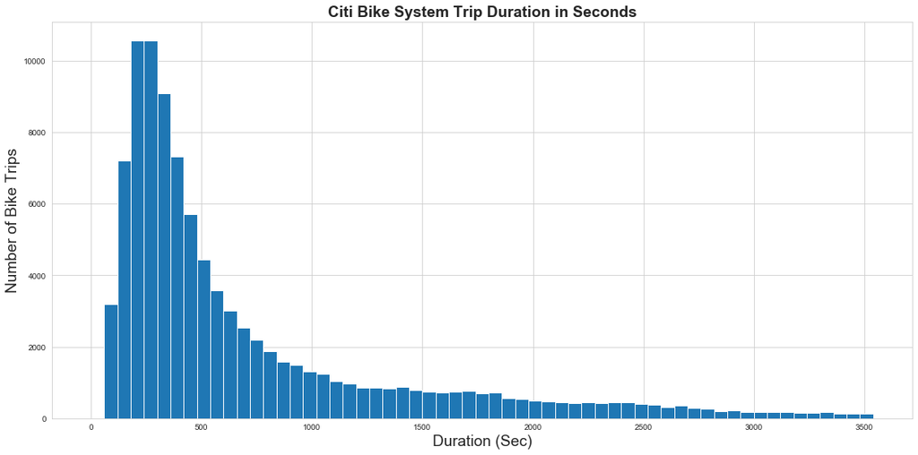

```python
# Duration of the bike rides - in SECONDS
bin_edges = np.arange(0, 3600, 60)
plt.figure(figsize = (19,9))

plt.hist(data = df_cleaned, x = 'trip_duration', bins = bin_edges);

plt.title("Citi Bike System Trip Duration in Seconds", fontsize = 19, fontweight='bold')
plt.xlabel('Duration (Sec)', fontsize = 19)
plt.ylabel('Number of Bike Trips', fontsize = 19);
```

*Duration of the bike rides - in Minutes*

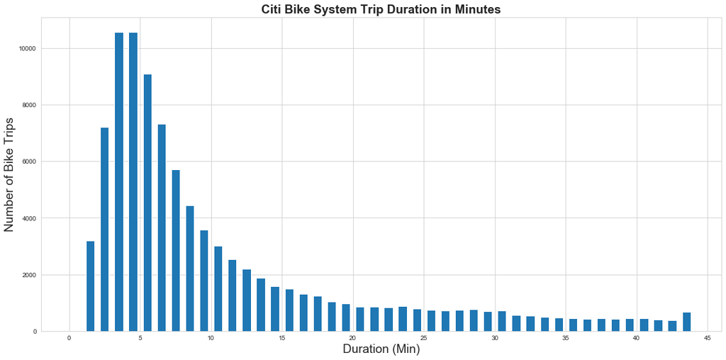

```python
# Duration of the bike rides -in MINUTES
plt.figure(figsize = (19,9))
bin_edges = np.arange(0, 45, 1)
ticks = [0, 5, 10, 15, 20, 25, 30,  35, 40, 45]
labels = ['{}'.format(val) for val in ticks]

plt.hist(data = df_cleaned, x = 'duration_min', bins = bin_edges, rwidth = 0.6);

plt.title("Citi Bike System Trip Duration in Minutes", fontsize = 19, fontweight='bold')
plt.xlabel('Duration (Min)', fontsize = 19)
plt.xticks(ticks, labels)
plt.ylabel('Number of Bike Trips', fontsize = 19);
```

### *Distance in kilometers traveled*

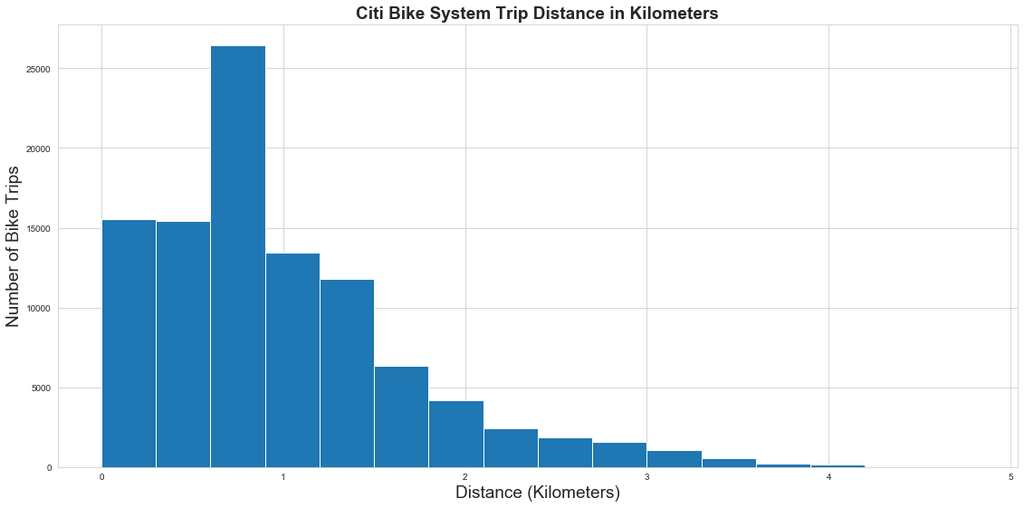

```python
# Distance in miles traveled
bin_edges = np.arange(0, 5, 0.3)
plt.figure(figsize = (19,9))
plt.hist(data = df_cleaned, x = 'distance_km', bins = bin_edges);

plt.title("Citi Bike System Trip Distance in Kilometers", fontsize = 19, fontweight = 'bold')
plt.xlabel('Distance (Kilometers)', fontsize = 19)
plt.ylabel('Number of Bike Trips', fontsize = 19);
```

### *Age group data*

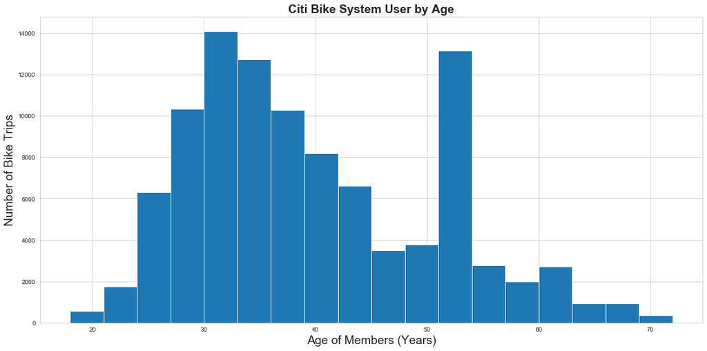

```python
# Age group data
bin_edges = np.arange(18, 75, 3)
plt.figure(figsize = (19,9))

plt.hist(data = df_cleaned, x = 'member_age', bins = bin_edges);

plt.title("Citi Bike System User by Age", fontsize = 19, fontweight = 'bold')
plt.xlabel('Age of Members (Years)', fontsize = 19)
plt.ylabel('Number of Bike Trips', fontsize = 19);
```

### *Usage by Females and Males*

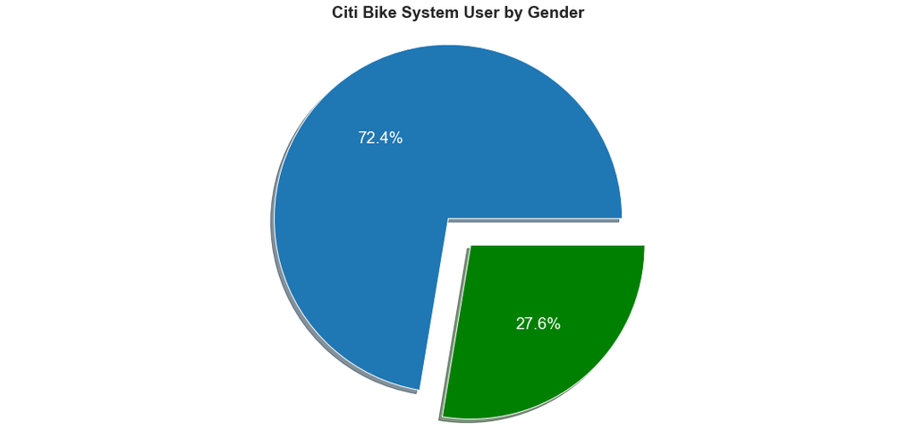

```python
# Usage by females, males, and other
gender = df_cleaned.gender.value_counts()

plt.figure(figsize = (19,9))
explode =(0.1,0.1)
plt.pie(gender, labels = ['Male', 'Female'], explode = explode, shadow = True, autopct = '%1.1f%%', colors = [base_color, 'green'],
       textprops={'color':"w", 'fontsize': 19});
plt.axis('equal')
plt.title('Citi Bike System User by Gender', fontsize = 19, fontweight = 'bold');
```

*The visual above demonstrates the overwhelming majority of users of the bike share system are male, representing 72% of the total users.*

### Discuss the distribution(s) of your variable(s) of interest. Were there any unusual points? Did you need to perform any transformations?

*No transformation was needed for the analysis as most of the transformations are done in preliminary wrangling. The distributions are not normal in any plot and are mostly skewed.*

### Of the features you investigated, were there any unusual distributions? Did you perform any operations on the data to tidy, adjust, or change the form of the data? If so, why did you do this?

*Nothing seems out of the normal expectations for a bike sharing system in a major city. So far, the data reveals that adults in the average working age range are the primary user base for the system, and they use the bikes on their daily commutes. People in their 50s use bikes a lot, that they may be using it as an exercise, and people take bikes for smaller distances.*

## Bivariate Exploration

*In this section, I investigate relationships between pairs of variables in the data.*

### *Customers vs Subscribers*

```python
# Customers vs Subscribers
customer = df_cleaned.query('user_type == "Customer"').shape[0]
subscriber = df_cleaned.query('user_type == "Subscriber"').shape[0]
customer_prop = customer / df_cleaned.shape[0]
subscriber_prop = subscriber / df_cleaned.shape[0]
```

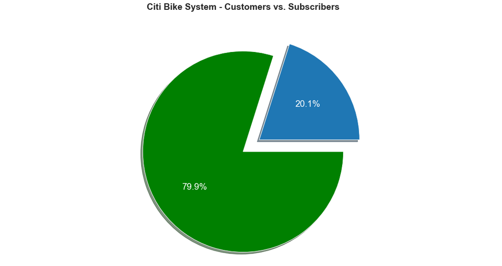

```python
# Customers vs Subscribers Visuals
# pie chart
plt.figure(figsize = [19, 9])

labels = ['Customer', 'Subscriber']
size = [customer_prop, subscriber_prop]
explode = (0.1 , 0.1)

plt.pie(size, explode = explode, labels = labels, autopct='%1.1f%%', shadow = True, colors = [base_color, 'green'], textprops={'color':"w", 'fontsize': 19});

plt.axis('equal')

plt.suptitle('Citi Bike System - Customers vs. Subscribers', fontsize = 19, fontweight = 'bold');
```

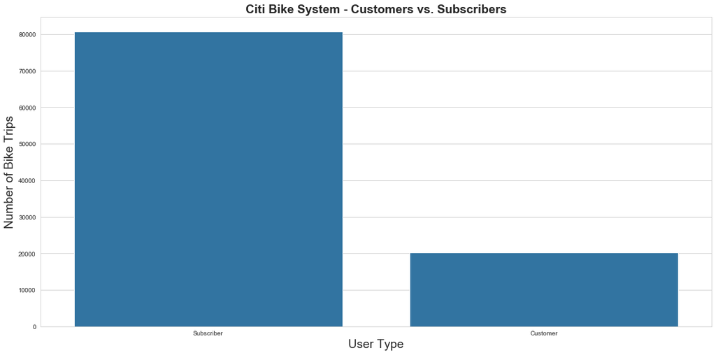

```python
# Customers vs Subscribers Visuals
# bar chart
plt.figure(figsize = [19, 9])

sb.countplot(data = df_cleaned, x = "user_type", order = df_cleaned.user_type.value_counts().index, color = base_color);
plt.xlabel('User Type', fontsize = 19);
plt.ylabel('Number of Bike Trips', fontsize = 19);
plt.title('Citi Bike System - Customers vs. Subscribers', fontsize = 19, fontweight='bold');
```

### *Customer Usage by Month vs. Subscriber Usage by Month*

```python
k = df_cleaned.groupby(['user_type', 'start_time_month']).size()
k = k.reset_index(name = 'count')
```

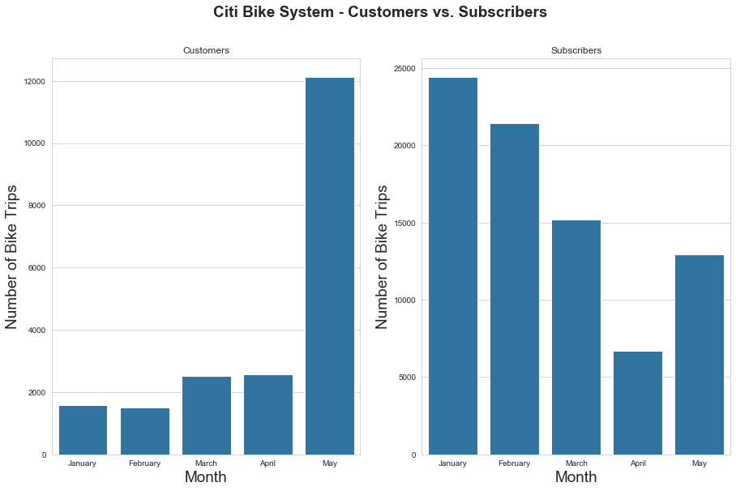

```python
# Customer Usage by Month vs. Subscriber Usage by Month
plt.figure(figsize = [15, 9])

order = ['January', 'February', 'March', 'April', 'May']

plt.subplot(1,2,1)
sb.barplot(data = k[k.user_type == 'Customer'], x = 'start_time_month', y = 'count', color = base_color, order = order);
plt.xlabel("Month", fontsize = 19)
plt.ylabel("Number of Bike Trips", fontsize = 19);
plt.title('Customers')

plt.subplot(1,2,2)
sb.barplot(data = k[k.user_type == 'Subscriber'], x = 'start_time_month', y = 'count', color = base_color, order = order);
plt.xlabel("Month", fontsize = 19)
plt.ylabel("Number of Bike Trips", fontsize = 19);
plt.title('Subscribers')

plt.suptitle('Citi Bike System - Customers vs. Subscribers', fontsize = 19, fontweight='bold');
```

*From previous analysis, we suggested that bike riding is high in January, February and May but these results are effected by user type.*

- *Customers: demand is high around summertime, reaching its peak in May. Customers are most probably tourists, or the occasional riders who visit the New York.*
- *Subscribers: the highest demand is from January to March, with it's peak in January. Subscribers are most likely riders using the bikes for their daily commute and exercise.*

### *Customer Usage by Weekday vs. Subscriber Usage by Weekday*

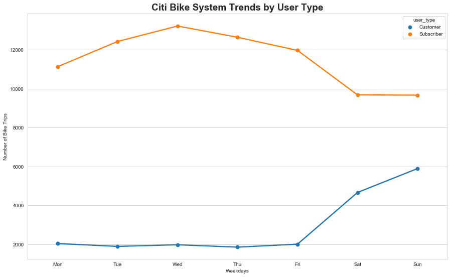

```python
# Customer Usage by Weekday vs. Subscriber Usage by Weekday
plt.figure(figsize=(15, 9))

df_cleaned_user_week = df_cleaned.groupby(['start_time_weekday', 'user_type']).size().reset_index(name = 'count')
weekday = ['Mon', 'Tue', 'Wed', 'Thu', 'Fri', 'Sat', 'Sun']

sb.pointplot(data = df_cleaned_user_week, x = 'start_time_weekday', y = 'count', hue = 'user_type', scale = .9, order = weekday);

plt.title('Citi Bike System Trends by User Type', fontsize = 19, fontweight='bold')
plt.xlabel('Weekdays')
plt.ylabel('Number of Bike Trips');
```

### *Customer Usage by Distance vs. Subscriber Usage by Distance*

[figure not shown]

```python
# Customer Usage by Distance vs. Subscriber Usage by Distance
plt.figure(figsize=(15, 9))
pl = df_cleaned.groupby('user_type')['distance_km'].size().reset_index()
sb.barplot(data = pl, x = 'user_type', y = 'distance_km', color = base_color);

plt.title('Citi Bike System Distance (Kilometers) by User Type', fontsize = 19, fontweight='bold')
plt.xlabel('User Type', fontsize = 19)
plt.ylabel('Distance Traveled (Kilometers)', fontsize = 19);
```

### *Customer Usage by Duration vs. Subscriber Usage by Duration*

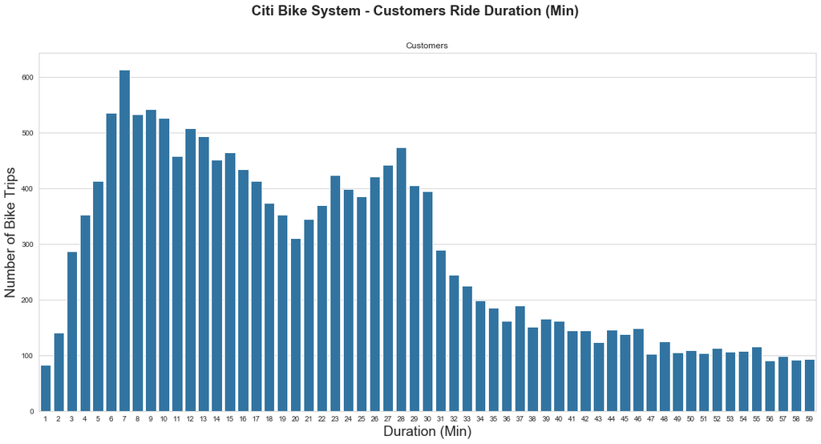

```python
# Customer Usage by Duration vs. Subscriber Usage by Duration
data = df_cleaned.query('duration_min < 60')
data1 = df_cleaned.query('duration_min < 60  and user_type == "Customer"');
data2 = df_cleaned.query('duration_min < 60  and user_type == "Subscriber"')

plt.figure(figsize = (19,9))

sb.countplot(data = data1, x = 'duration_min', color = base_color)
plt.xlabel('Duration (Min)', fontsize = 19)
plt.ylabel('Number of Bike Trips', fontsize = 19)
plt.title('Customers');

plt.suptitle('Citi Bike System - Customers Ride Duration (Min)', fontsize = 19, fontweight='bold');
```

[figure not shown]

```python
plt.figure(figsize = (19,9))

sb.countplot(data = data2, x = 'duration_min', color = base_color)
plt.xlabel('Duration (Min)', fontsize = 19)
plt.ylabel('Number of Bike Trips', fontsize = 19)
plt.title('Customers');

plt.suptitle('Citi Bike System - Subscribers Ride Duration (Min)', fontsize = 19, fontweight='bold');
```

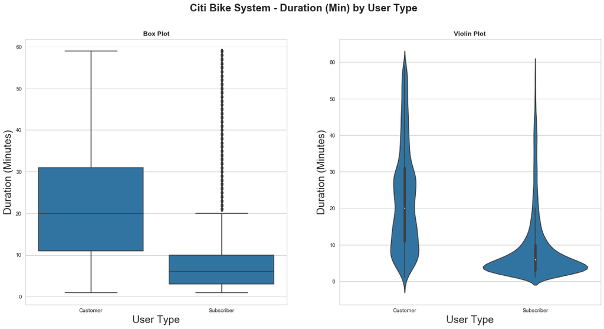

```python
data = df_cleaned.query('duration_min < 60')

plt.figure(figsize = (19,9))
plt.subplot(1,2,1)
sb.boxplot(data = data, x = 'user_type', y = 'duration_min', color = base_color)
plt.xlabel('User Type', fontsize=19)
plt.ylabel('Duration (Minutes)', fontsize=19)
plt.title('Box Plot', fontweight = 'bold')

plt.subplot(1,2,2)
sb.violinplot(data = data, x = 'user_type', y = 'duration_min', color = base_color)
plt.xlabel('User Type', fontsize=19)
plt.ylabel('Duration (Minutes)', fontsize=19)
plt.title('Violin Plot', fontweight = 'bold')

plt.suptitle('Citi Bike System - Duration (Min) by User Type', fontsize=19,fontweight='bold');
```

### *Customer vs. Subscriber Usage by Age*

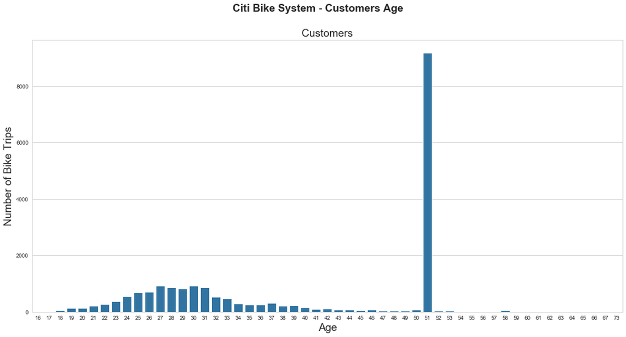

```python
# Customer vs. Subscriber Usage by Age
data1 = df_cleaned.query('member_age < 75  and user_type == "Customer"');
data2 = df_cleaned.query('member_age < 75  and user_type == "Subscriber"')

plt.figure(figsize = (19,9))

sb.countplot(data = data1, x = 'member_age', color = base_color)
plt.xlabel('Age', fontsize = 19)
plt.ylabel('Number of Bike Trips', fontsize = 19)
plt.title('Customers', fontsize = 19);

plt.suptitle('Citi Bike System - Customers Age', fontsize = 19, fontweight='bold');
```

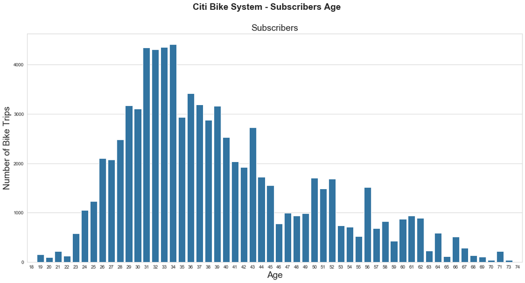

```python
plt.figure(figsize = (19,9))

sb.countplot(data = data2, x = 'member_age', color = base_color)
plt.xlabel('Age', fontsize = 19)
plt.ylabel('Number of Bike Trips', fontsize = 19)
plt.title('Subscribers', fontsize = 19);

plt.suptitle('Citi Bike System - Subscribers Age', fontsize = 19, fontweight='bold');
```

### Did you observe any interesting relationships between the other features (not the main feature(s) of interest)?

*There is a difference in the trip duration between customers and subscribers. Customers trips are usually longer than for subscribers, most probably due to the fact they prefer bike rides around weekends in summertime, which may be for longer trips around the surrounding area. Subscribers use the system mainly for commute purposes so they prefer quick, short rides to and from work.*

## Multivariate Exploration

*I created plots of three or more variables to investigate the Citi Bike data even further.*

### *Monthly usage - User Type and Gender*

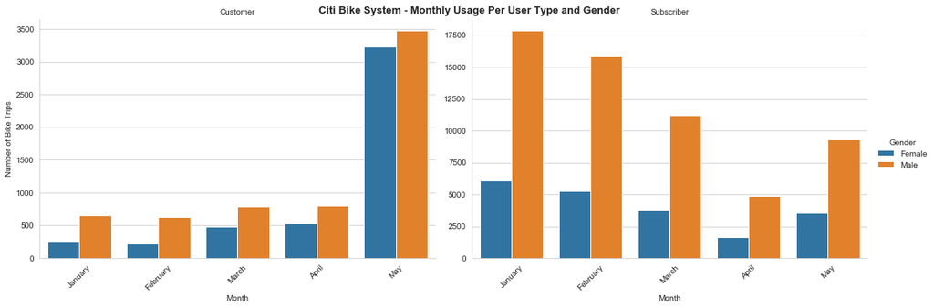

```python
# Monthly usage - user type and gender
plt.figure(figsize = (19,9))
graph = sb.catplot(data=df_cleaned, x='start_time_month', col="user_type", hue="gender", kind='count', sharey = False, aspect = 1.5);

graph.set_axis_labels("Month", "Number of Bike Trips")
graph._legend.set_title('Gender')
graph.set_titles("{col_name}")

graph.fig.suptitle('Citi Bike System - Monthly Usage Per User Type and Gender', fontsize = 13, fontweight='bold');
graph.set_xticklabels(rotation = 45);
```

*(Note the y-axis isn't shared between the Customer and Subscriber graphs in order to visualize trends easier). The trend for males and females is little similar for customers, the highest demand is around summertime, reaching its peak in May. For subscribers, the highest demand is from January and February, with it's peak in January. Women opts for bike riding less than Men as there numbers are low whether for Customers and Subscribers.*

### *Trip duration (min) per User Type and Gender*

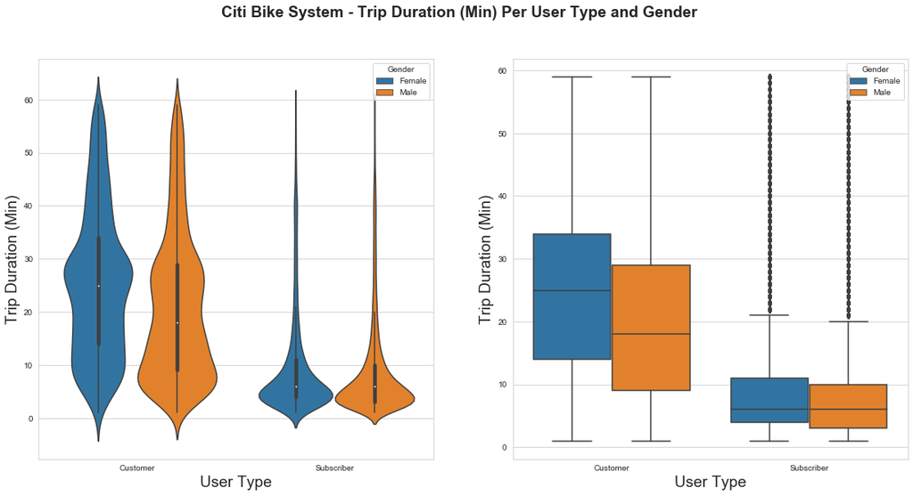

```python
# Violinplot - duration (min) per user type and gender
plt.figure(figsize = (19,9))
plt.subplot(1,2,1)
sb.violinplot(data = df_cleaned.query('duration_min < 60'), x = 'user_type', y = "duration_min", hue = "gender");

plt.xlabel("User Type", fontsize = 19)
plt.ylabel("Trip Duration (Min)", fontsize = 19)
plt.legend(title = 'Gender', loc = 1)
# Box plot
plt.subplot(1,2,2)
sb.boxplot(data = df_cleaned.query('duration_min < 60'), x = 'user_type', y = "duration_min", hue = "gender");

plt.xlabel("User Type", fontsize = 19)
plt.ylabel("Trip Duration (Min)", fontsize = 19)
plt.legend(title = 'Gender', loc = 1)
plt.suptitle('Citi Bike System - Trip Duration (Min) Per User Type and Gender', fontsize = 19, fontweight='bold');
```

*In both cases, females take longer trips (measured in time) than males. The difference is more visible for customers (~17 min for males vs ~25 for females) than for subscribers (the difference is quite small).*

### *Customers Monthly Bike Rides by Age Groups*

```python
#Creating age bins and counting number of trips using bike_id column by applying
# pandas .agg function.
customer_df = df_cleaned.query('user_type == "Customer" and member_age < 75').groupby(['start_time_month', 'age_bins']).agg({'bike_id':'count'}).reset_index()
customer_df.rename(columns = {'bike_id':'count'}, inplace = True)
```

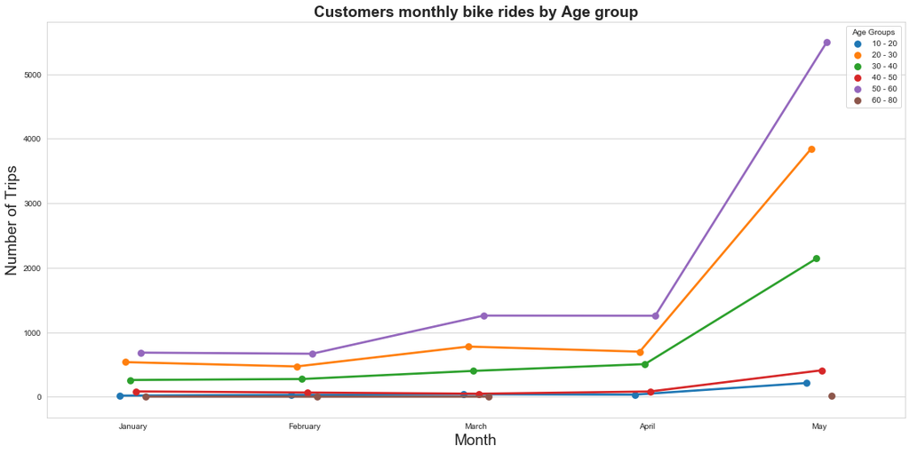

```python
# Creating plot
plt.figure(figsize = (19,9))
order = ['January', 'February', 'March', 'April', 'May']
sb.pointplot(data = customer_df, x = 'start_time_month', y = 'count', hue = 'age_bins', dodge = True, ci = 'sd', order = order)

plt.title("Customers monthly bike rides by Age group", fontsize = 19,fontweight = 'bold')
plt.xlabel('Month', fontsize = 19)
plt.ylabel('Number of Trips', fontsize = 19);
plt.legend(title = 'Age Groups');
```

*Customers with age group 50 to 60 uses bike ride the most followed by the customer sfrom the age group 20 to 30. The lowest usage is from customers from 60 - 80 which is not surprising as most of them at this age are not able to ride a bike. Also bike rides among customers peaked at month of May.*

### *Subscribers Monthly Bike Rides by Age Groups*

```python
subscriber_df = df_cleaned.query('user_type == "Subscriber" and member_age < 75').groupby(['start_time_month', 'age_bins']).agg({'bike_id':'count'}).reset_index()
subscriber_df.rename(columns = {'bike_id':'count'}, inplace = True)
```

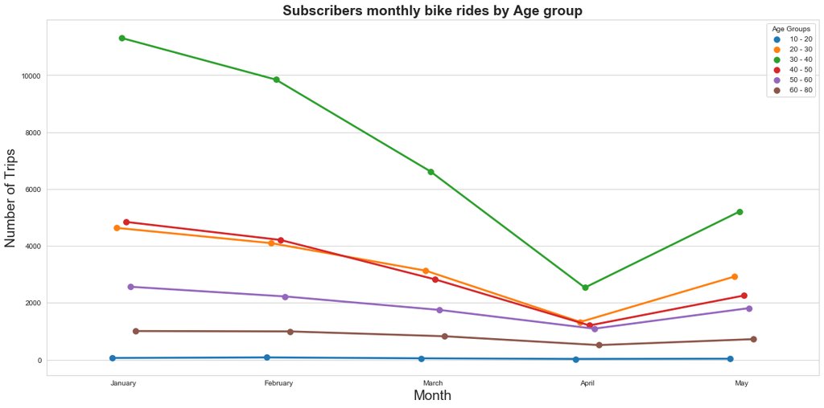

```python
# Creating plot
plt.figure(figsize = (19,9))
sb.pointplot(data = subscriber_df, x = 'start_time_month', y = 'count', hue = 'age_bins', dodge = True, ci = 'sd', order = order)

plt.title("Subscribers monthly bike rides by Age group", fontsize = 19,fontweight = 'bold')
plt.xlabel('Month', fontsize = 19)
plt.ylabel('Number of Trips', fontsize = 19);
plt.legend(title = 'Age Groups');
```

*Most subscribers are from age of 30 -40 and use the bike rides the most followed by age group of 40-50 and 20-30. However, subscribers use bikes most in January.*

### Talk about some of the relationships you observed in this part of the investigation. Were there features that strengthened each other in terms of looking at your feature(s) of interest?

*This section essentially amplified the previous data topics of exploration through visuals and adding more variables to compare. Subscribers vs Customers age was expanded upon through the use of age groups, and a pointplot to demonstrate the difference between each age group.*

### Were there any interesting or surprising interactions between features?

*Nothing out of the expected here. It was interesting to note the sharp monthly difference for males vs. females, and how differnt the female count got to the male Customer count in January through May. This may be a potential loss of possible Customers converting to Subscribers.*

## Summary

*Citi Bikes is a A fun and affordable way to get around town:*

## Sources

- [Citi Bike Data Set](https://www.citibikenyc.com/system-data)
- [Haversine formula](https://www.movable-type.co.uk/scripts/latlong.html) used to calculate distances using latitude and longitude
- [Seaborn catplot](https://seaborn.pydata.org/generated/seaborn.catplot.html) documentation
- [IPython Display](https://ipython.org/ipython-doc/3/api/generated/IPython.display.html) documentation